# Metagenome QC analysis

Published

7 Sep 2025

In this Quarto document, we perform quality control on the tissue samples and compare them with the vaginal swab samples.

The steps performed are as follows:

1. Identify low quality samples
2. Remove spike-in
3. Remove low qualit samples and samples with zero counts after spike-in removal
4. Filter out taxa with low abundance across samples at every level
5. Visualize taxonomy (barplot)
6. Rarefy

visualize tissue samples before and after spike-in?

### Load Libraries

```r
##################
# LOAD LIBRARIES #
##################
library(tidyverse)
library(RColorBrewer)
library(scales)
select <- dplyr::select

#################
# COLOUR PALLET #
#################
pal <- c(
  #scales::hue_pal()(8),
  c(
    "#4E79A7",
    "#F28E2B",
    "#E15759",
    "#76B7B2",
    "#59A14F",
    "#EDC948",
    "#B07AA1",
    "#FF9DA7",
    "#9C755F",
    "#BAB0AC"
  ),
  RColorBrewer::brewer.pal(8, "Set2"),
  RColorBrewer::brewer.pal(8, "Accent"),
  RColorBrewer::brewer.pal(8, "Pastel2"),
  RColorBrewer::brewer.pal(9, "Pastel1"),
  RColorBrewer::brewer.pal(9, "Set1")
)
taxonomy <- c(
  "kingdom",
  "phylum",
  "class",
  "order",
  "family",
  "genus",
  "species",
  "strain"
)

#########
# PATHS #
#########
input_dir <- "../data/"

vagswab_counts_path <- "../Tidy_data/Metagenomics/Metageonome_all_vagswab_metaphlan.csv"
tissue_counts_path <- "../Tidy_data/Metagenomics/Metageonome_all_tissue_metaphlan.csv"

count_info_vagswab_path <- "../Tidy_data/Metagenomics/Read_count_info_vaginalswab.csv"
count_info_tissue_path <- "../Tidy_data/Metagenomics/Read_count_info_tissue.csv"
```

### Load Data

```r
#############
# LOAD DATA #
#############
vagswab_counts <- read_csv(vagswab_counts_path)
tissue_counts <- read_csv(tissue_counts_path)
count_info_vagswab <- read_csv(count_info_vagswab_path)
count_info_tissue <- read_csv(count_info_tissue_path)
```

## Understanding the data

The dataset delivered from the sequencing team is structured as follows:

Each **row** represents a taxon and each **column** represents a sample.

- Each row corresponds to one taxon, described hierarchically in the `clade_name` column.
- `clade_name` encodes the taxonomy from  
  *kingdom → phylum → class → order → family → genus → species → strain*,  
  separated by `"|"` and prefixed with `"k__"`, `"p__"`, `"c__"`, etc.
- Each sample column contains the **relative abundance (%)** of that taxon in that sample.
- Importantly, the values are **already percentages**, not counts.  
  This means that when the rows are grouped by taxonomic level, the abundances sum to **100%** (or 0% if no taxa remain after filtering) for each individual sample.

This is demonstrated in the code below:

```r
t <- set_names(taxonomy, seq_along(taxonomy))
sample_cols <- names(tissue_counts)[-c(1)]

tissue_long <- tissue_counts %>%
  mutate(
    level = factor(
      t[as.character(str_count(clade_name, "\\|") + 1)],
      levels = taxonomy
    ),
    .after = "clade_name"
  ) %>%
  group_by(level) %>%
  summarise(across(all_of(sample_cols), ~ sum(.))) %>%
  pivot_longer(
    where(is.numeric),
    names_to = "sample",
    values_to = "abundance"
  )

# Now we select a single sample and see that it adds up to a 100 for each level
tissue_long %>%
  filter(sample == "S30")
```

```
# A tibble: 8 × 3
  level   sample abundance
  <fct>   <chr>      <dbl>
1 kingdom S30          100
2 phylum  S30          100
3 class   S30          100
4 order   S30          100
5 family  S30          100
6 genus   S30          100
7 species S30          100
8 strain  S30          100
```

For example, the row `k__Bacteria|p__Bacteroidota|c__Bacteroidia|o__Bacteroidales|f__Prevotellaceae` represents the taxon *family* *Prevotellaceae* within the *phylum* *Bacteroidota*, and the entry in sample `S60` shows its relative abundance in that sample.

```r
tissue_counts %>%
  mutate(
    level = factor(
      t[as.character(str_count(clade_name, "\\|") + 1)],
      levels = taxonomy
    ),
    .after = "clade_name"
  ) %>%
  select(clade_name, level, S60) %>%
  filter(level == "family") %>%
  filter(S60 != 0)
```

```
# A tibble: 8 × 3
  clade_name                                                        level    S60
  <chr>                                                             <fct>  <dbl>
1 k__Bacteria|p__Firmicutes|c__Bacilli|o__Bacillales|f__Alicycloba… fami… 17.4
2 k__Bacteria|p__Actinobacteria|c__Actinomycetia|o__Bifidobacteria… fami… 41.5
3 k__Bacteria|p__Fusobacteria|c__Fusobacteriia|o__Fusobacteriales|… fami…  0.399
4 k__Bacteria|p__Actinobacteria|c__Actinomycetia|o__Actinomycetale… fami…  6.05
5 k__Bacteria|p__Bacteroidota|c__Bacteroidia|o__Bacteroidales|f__P… fami… 23.1
6 k__Bacteria|p__Actinobacteria|c__Coriobacteriia|o__Coriobacteria… fami…  1.16
7 k__Bacteria|p__Firmicutes|c__Negativicutes|o__Veillonellales|f__… fami…  5.66
8 k__Bacteria|p__Bacteroidota|c__Bacteroidia|o__Bacteroidales|f__M… fami…  0.104
```

This structure makes it possible to:

- **Collapse or expand** to different taxonomic levels.
- **Check internal consistency**, since within each level the abundances across taxa sum to 100%.
- **Easily visualize** community composition at different levels.

The purpose of this section is to help students in the lab — and my future self — to quickly grasp the structure of the data and serve as an introduction to a tutorial on how to perform QC on shotgun metagenome data.

controls include sequencing negative controls and extraction negative controls. Some samples have been run twice in individual runs (vagswab) or as new extractions (tissue)

## Identify matching samples

```r
# Identify matching samples between vagswab and tissue df
intersection <- intersect(
  colnames(vagswab_counts)[-1],
  colnames(tissue_counts)[-1]
)

smpls <- tibble(vagswab = intersection, tissue = intersection) %>%
  add_case(vagswab = setdiff(names(vagswab_counts)[-1], intersection)) %>%
  add_case(tissue = setdiff(names(tissue_counts)[-1], intersection)) %>%
  filter(if_any(everything(.), ~ !(str_detect(., "_ex|_seq|_Seq")))) %>%
  # get sample type:
  mutate(
    type = ifelse(
      str_detect(coalesce(tissue, vagswab), "_"),
      str_extract(coalesce(tissue, vagswab), "1W|1M|3M|BL|6M"),
      "S"
    )
  )

# check that all samples are overlaping between the count_info table and the count tables
setdiff(names(vagswab_counts)[-1], count_info_vagswab$svamp_ID)
```

```
character(0)
```

```r
setdiff(count_info_vagswab$svamp_ID, names(vagswab_counts)[-1])
```

```
character(0)
```

```r
setdiff(names(tissue_counts)[-1], count_info_tissue$svamp_ID)
```

```
character(0)
```

```r
setdiff(count_info_tissue$svamp_ID, names(tissue_counts)[-1])
```

```
character(0)
```

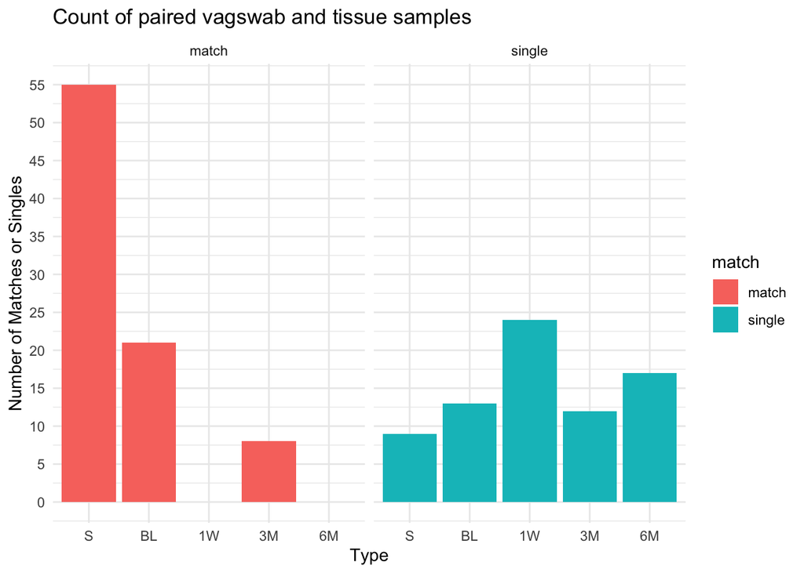

```r
###############################################
# VISUALIZE PAIRED TISSUE AND VAGSWAB SAMPLES #
###############################################
lvl <- c("S", "BL", "1W", "3M", "6M", "1M")
smpls %>%
  mutate(type = factor(.$type, levels = lvl)) %>%
  mutate(
    match = if_else(vagswab == tissue, "match", "single", missing = "single")
  ) %>%
  # filter(match) %>% # keep only matches
  ggplot(aes(x = type)) +
  geom_bar(aes(fill = match)) +
  scale_y_continuous(breaks = seq(0, 160, 5)) + # breaks every 5
  labs(
    title = "Count of paired vagswab and tissue samples",
    x = "Type",
    y = "Number of Matches or Singles"
  ) +
  theme_minimal() +
  facet_wrap(~match)
```

## Counts before spike-in removal

```r
# Identify samples with low total reads < 20 million total reads (human + bacterial)
count_info_vagswab %>%
  filter(after_fastp < 20000000) %>% # 1 sample
  knitr::kable()
```

| Sample | barcode_shotgun_swab | DS_ID | svamp_ID | ID | duplication | before_fastp | after_fastp | after_kraken2_host_removal |
| --- | --- | --- | --- | --- | --- | --- | --- | --- |
| 242_MiKantarell__FF06581440__E200019430_L1_72_ | FF06581440 | K10 | S10 | S10 | 0.0004724 | 12701 | 12691 | 10805 |

```r
count_info_tissue %>%
  filter(after_fastp < 20000000) # 0 samples
```

```
# A tibble: 0 × 12
# ℹ 12 variables: Flowcell_L1_bc <chr>, BEA_ID <chr>,
#   barcode_shotgun_tissue <chr>, DS_ID <chr>, svamp_ID <chr>,
#   extraction_plate_id <chr>, not_sequenced <lgl>, ID <chr>,
#   duplication <dbl>, before_fastp <dbl>, after_fastp <dbl>,
#   after_kraken2_host_removal <dbl>
```

```r
# check bacterial reads bellow 100k
count_info_vagswab %>%
  filter(after_kraken2_host_removal < 100000) %>%
  knitr::kable()
```

| Sample | barcode_shotgun_swab | DS_ID | svamp_ID | ID | duplication | before_fastp | after_fastp | after_kraken2_host_removal |
| --- | --- | --- | --- | --- | --- | --- | --- | --- |
| 242_MiKantarell__FF06581440__E200019430_L1_72_ | FF06581440 | K10 | S10 | S10 | 0.0004724 | 12701 | 12691 | 10805 |

```r
count_info_tissue %>%
  filter(after_kraken2_host_removal < 100000)
```

```
# A tibble: 0 × 12
# ℹ 12 variables: Flowcell_L1_bc <chr>, BEA_ID <chr>,
#   barcode_shotgun_tissue <chr>, DS_ID <chr>, svamp_ID <chr>,
#   extraction_plate_id <chr>, not_sequenced <lgl>, ID <chr>,
#   duplication <dbl>, before_fastp <dbl>, after_fastp <dbl>,
#   after_kraken2_host_removal <dbl>
```

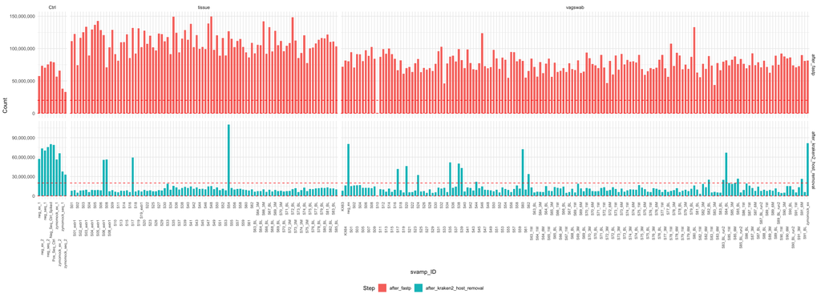

```r
###############################
# VISUALIZE COUNTS PER SAMPLE #
###############################
l <- list("vagswab" = count_info_vagswab, "tissue" = count_info_tissue)

df <- l %>%
  imap(
    ~ .x %>%
      select(., svamp_ID, after_fastp, after_kraken2_host_removal) %>%
      mutate(., type = .y) %>%
      mutate(
        .,
        type = ifelse(str_detect(.$svamp_ID, "_ex_|_seq|_Seq"), "Ctrl", .$type)
      )
  ) %>%
  bind_rows()

count_info <- df %>%
  pivot_longer(
    cols = c(after_fastp, after_kraken2_host_removal),
    names_to = "step",
    values_to = "count"
  ) %>%
  mutate(svamp_ID = factor(.$svamp_ID, levels = unique(sort(.$svamp_ID))))
#mutate(
#svamp_ID = fct_reorder(svamp_ID, count)  # reorders within facet
#)

p <- ggplot(count_info, aes(x = svamp_ID, y = count, fill = step)) +
  geom_col(width = 0.7, position = "dodge") +
  facet_grid(step ~ type, scales = "free", drop = TRUE, space = "free") +
  scale_x_discrete(guide = guide_axis(n.dodge = 2)) +
  scale_y_continuous(labels = label_comma()) + # <-- commas
  theme_minimal() +
  theme(
    legend.position = "bottom",
    axis.text.x = element_text(angle = 90, vjust = 0.5, hjust = 1, size = 7)
  ) +
  labs(x = "svamp_ID", y = "Count", fill = "Step") +
  # Add red horizontal lines
  geom_hline(yintercept = 20000000, color = "red", linetype = "dashed") +
  geom_hline(yintercept = 2000, color = "red", linetype = "dashed")

p
```

```r
ggsave(
  "../Results/Tissue_QC/counts_vagswab_and_tissue_plot.png",
  p,
  width = 22,
  height = 8,
  bg = "white"
)
```

The upper red dashed line marks 20 million reads, the lower cut-off used to flag vagswab samples with insufficient sequencing depth. At the **after_fastp stage**, these counts include reads of both bacterial and human origin.

The **after_kraken2_host_removal** stage reflects only bacterial reads, after human-derived sequences have been filtered out.

Before host removal, tissue samples generally have higher read counts, as you could expect, since biopsy samples naturally contain more DNA which are largly derived from the host.

After host removal, there is a sharp decline in counts for most samples, with the majority now falling between 20 million and 10,000 reads. At this stage, vagswab and tissue samples appear more similar in read counts. However, the tissue samples were sequenced with a bacterial spike-in, which must be removed before making direct comparisons between the two sample types.

The spike in is bateria is “s__Alicyclobacillus_acidiphilus_t__SGB30417”

## Remove-spike-in

#### Gabriellas version (only strain level)

```r
# Gabriellas code for removing spike-in:
#  - Keeps only the species_strain table.
#  - Renormalizes so that species_strain abundances sum to 100% per sample.
#  - Higher taxonomic levels (family, genus, etc.) would thus need to be
#    recalculated from the renormalized species_strain to be used later.

###################
# REMOVE SPIKE-IN #
###################
# Make a "species_strain" column to identify the spike-in
tissue_counts_clean <- tissue_counts %>%
  separate(
    col = clade_name,
    into = taxonomy,
    sep = "\\|",
    fill = "right"
  ) %>%
  mutate(species_strain = paste0(species, "_", strain)) %>%
  # filters out any rows which sums to zero:
  filter(if_any(where(is.double), ~ .x > 0)) %>%

  # removes any rows with species and strain as NA
  filter(!species_strain %in% "NA_NA") %>%
  filter(!strain %in% NA) %>%
  # select only the specie_strain taxa column:
  select(species_strain, where(is.double)) %>%

  # remove the spike-in bacteria
  filter(!species_strain %in% "s__Alicyclobacillus_acidiphilus_t__SGB30417") %>%
  # remove any taxonomic rows that have zero relative abundance in all samples
  filter(if_any(where(is.double), ~ .x > 0))

dim(tissue_counts_clean) # 41 taxa in 94 samples

##############################
# REMOVE ZERO COLSUM SAMPLES #
##############################
# removes samples with colsum = zero (55 smaples + neg ctrl)
tissue_counts_clean <- tissue_counts_clean %>%
  # see which samples sums to zero:
  # select(species_strain, where(~ is.numeric(.x) && sum(.x, na.rm = TRUE) == 0) )
  select(
    "species_strain",
    where(~ is.numeric(.x) && sum(.x, na.rm = TRUE) != 0)
  )

dim(tissue_counts_clean) # 41 taxa in 38 samples

####################
# BACTERIAL COUNTS #
####################
# look at the total bacterial count after removing the Alicyclobacillus
tissue_counts_clean %>%
  summarise(across(where(is.double), ~ sum(.x, na.rm = TRUE))) %>% # column sums
  pivot_longer(everything(), names_to = "svamp_ID", values_to = "relab") %>% # long format
  left_join(count_info_tissue, by = "svamp_ID") %>% # add count info
  mutate(
    bac_counts_no_spikein = relab * after_kraken2_host_removal / 100,
    .after = "relab"
  ) %>%
  {
    . ->> count_info_tissue_no_spike
  } %>%
  filter(bac_counts_no_spikein < 2000) # one sample (S19, 372 bacterial reads)


#######################################
# RE-NORMALIZE AFTER SPIKE-IN REMOVAL #
#######################################
tissue_counts_renorm <- tissue_counts_clean %>%
  # remove ctrl and low bacteria sample
  select(-Pos_Seq_Ctrl, -S19) %>%
  # transpose:
  pivot_longer(-species_strain, names_to = "svamp_ID", values_to = "value") %>%
  pivot_wider(names_from = "species_strain", values_from = "value") %>%

  # Add relab and bac_counts_no_spikein information:
  left_join(
    select(count_info_tissue_no_spike, svamp_ID, relab, bac_counts_no_spikein),
    .,
    by = "svamp_ID"
  ) %>%
  # Renormalize the relab for the actual taxa (without spike in) to 100%
  rowwise() %>%
  mutate(across(starts_with("s__"), ~ .x / relab * 100)) %>%
  mutate(ROW_SUM = sum(c_across(starts_with("s__"))), .after = "svamp_ID") %>%
  filter(bac_counts_no_spikein >= 2000, !(is.na(ROW_SUM))) %>%
  ungroup()

#############################
# PLOT RE-SEQUENCED SAMPLES #
#############################
n <- names(select(tissue_counts, contains("extr1")))
s <- str_remove(n, "_extr1")
n <- c(n, s) # samples sequenced twice

#inspect the read levels for samples sequenced twice:
df_long <- tissue_counts_renorm %>%
  filter(svamp_ID %in% n) %>%
  filter(if_any(starts_with("s__"), ~ .x > 0)) %>%
  pivot_longer(
    cols = starts_with("s__"),
    names_to = "species",
    values_to = "abundance"
  ) %>%
  filter(abundance != 0)

ggplot(df_long, aes(x = svamp_ID, y = abundance, fill = species)) +
  geom_col(position = "stack") +
  labs(
    x = "Sample ID",
    y = "Relative abundance (%)",
    fill = "Species"
  ) +
  theme_minimal() +
  theme(
    axis.text.x = element_text(angle = 45, hjust = 1)
  )

##################################
# SAVE RENORMALIZED STRAIN LEVEL #
##################################
tissue_counts_renorm_t <- tissue_counts_renorm %>%
  select(-ROW_SUM, -relab, -bac_counts_no_spikein, -ends_with("_extr1")) %>%
  # removes the second sequencing of sample S01 and S02:
  filter(!(grepl("_extr1", .$svamp_ID))) %>%
  # transpose:
  pivot_longer(-svamp_ID, names_to = "species_strain", values_to = "value") %>%
  pivot_wider(names_from = "svamp_ID", values_from = "value")

write_csv(
  tissue_counts_renorm_t,
  "../Results/Tissue_QC/Metageonome_all_tissue_metaphlan_no_spikein.csv"
)
write_csv(
  count_info_tissue_no_spike,
  "../Results/Tissue_QC/Read_count_info_tissue_no_spikein.csv"
)

# tissue_counts_renorm_t <- read_csv("../Results/Tissue_QC/Metageonome_all_tissue_metaphlan_no_spikein.csv")
```

#### My version (all taxonomy levels)

```r
# final version
###########################
# GET SPIKE-IN PERCENTAGE #
###########################
# 2. Get spike-in percentage per sample from strain level
spike_pct <- tissue_counts %>%
  filter(str_detect(
    clade_name,
    "s__Alicyclobacillus_acidiphilus\\|t__SGB30417"
  )) %>%
  pivot_longer(
    cols = where(is.double),
    names_to = "sample",
    values_to = "spike_pct"
  ) %>%
  select(sample, spike_pct) %>%
  deframe()

###########################################
# GET SPIKE-IN CLADE NAMES FOR ALL LEVELS #
###########################################
# identify taxa levels to remove spicke-in percentage from
# by looking at the Negative-spik-in control sample
spike_clade <- tissue_counts %>%
  filter(Neg_Seq_Ctrl_Spiked != 0) %>%
  select(clade_name) %>%
  deframe()


#########################################################
# REMOVE SPIKE-IN AND RE-NORMALIZE COUNTS AFTER REMOVAL #
#########################################################
t <- set_names(taxonomy, seq_along(taxonomy))
sample_cols <- names(tissue_counts)[-c(1)] # [-c(1,2,3)] removes ctrls

tissue_no_spike <- tissue_counts %>%
  # Identify the eight taxonomy levels
  mutate(
    level = factor(
      t[as.character(str_count(clade_name, "\\|") + 1)],
      levels = taxonomy
    ),
    .after = "clade_name"
  ) %>%

  # Remove spike-in row
  filter(
    !str_detect(clade_name, "s__Alicyclobacillus_acidiphilus\\|t__SGB30417")
  ) %>%

  # remove percentage spike-in from all other taxa levels
  mutate(
    across(
      all_of(sample_cols),
      ~ if_else(clade_name %in% spike_clade, .x - spike_pct[cur_column()], .x)
    )
  )

tissue_renorm <- tissue_no_spike %>%
  # Re-normalize per level & sample
  # nest(.by = level) %>%
  group_by(level) %>%
  mutate(across(
    all_of(sample_cols),
    ~ {
      total <- sum(.x, na.rm = TRUE) # sum for this sample at this level
      #if (total == 0) 0 else .x / total * 100
      pct <- spike_pct[cur_column()] # spike-in %
      if (pct == 100) 0 else .x / total * 100
    },
    .names = "{.col}"
  )) %>%
  ungroup()

# Test that all levels add up to 100 per sample
tissue_renorm %>%
  group_by(level) %>%
  summarise(across(where(is.double), ~ sum(.))) %>%
  pivot_longer(
    where(is.numeric),
    names_to = "sample",
    values_to = "abundance"
  ) %>%
  pivot_wider(names_from = "level", values_from = "abundance")
```

```
# A tibble: 94 × 9
   sample              kingdom phylum class order family genus species strain
   <chr>                 <dbl>  <dbl> <dbl> <dbl>  <dbl> <dbl>   <dbl>  <dbl>
 1 Neg_Seq_Ctrl_Spiked       0      0     0     0      0     0       0      0
 2 Pos_Seq_Ctrl            100    100   100   100    100   100     100    100
 3 S01                     100    100   100   100    100   100     100    100
 4 S01_extr1               100    100   100   100    100   100     100    100
 5 S02                     100    100   100   100    100   100     100    100
 6 S02_extr1               100    100   100   100    100   100     100    100
 7 S03                       0      0     0     0      0     0       0      0
 8 S03_extr1                 0      0     0     0      0     0       0      0
 9 S04                       0      0     0     0      0     0       0      0
10 S04_extr1                 0      0     0     0      0     0       0      0
# ℹ 84 more rows
```

```r
t <- tissue_renorm %>%
  select(1:2, "S60") %>%
  # Re-normalize per level & sample
  nest(.by = level)

t$data[[5]] %>% arrange(desc(S60))
```

```
# A tibble: 24 × 2
   clade_name                                                                S60
   <chr>                                                                   <dbl>
 1 k__Bacteria|p__Actinobacteria|c__Actinomycetia|o__Bifidobacteriales|f… 53.2
 2 k__Bacteria|p__Bacteroidota|c__Bacteroidia|o__Bacteroidales|f__Prevot… 29.6
 3 k__Bacteria|p__Actinobacteria|c__Actinomycetia|o__Actinomycetales|f__…  7.77
 4 k__Bacteria|p__Firmicutes|c__Negativicutes|o__Veillonellales|f__Veill…  7.26
 5 k__Bacteria|p__Actinobacteria|c__Coriobacteriia|o__Coriobacteriales|f…  1.49
 6 k__Bacteria|p__Fusobacteria|c__Fusobacteriia|o__Fusobacteriales|f__Le…  0.512
 7 k__Bacteria|p__Bacteroidota|c__Bacteroidia|o__Bacteroidales|f__Muriba…  0.133
 8 k__Bacteria|p__Firmicutes|c__Bacilli|o__Bacillales|f__Alicyclobacilla…  0
 9 k__Bacteria|p__Firmicutes|c__Bacilli|o__Lactobacillales|f__Lactobacil…  0
10 k__Bacteria|p__Candidatus_Saccharibacteria|c__Candidatus_Nanoperiomor…  0
# ℹ 14 more rows
```

```r
t_seq <- set_names(taxonomy, seq_along(taxonomy))
tissue_counts %>%
  mutate(
    level = t_seq[as.character(str_count(clade_name, "\\|") + 1)],
    .after = "clade_name"
  ) %>%
  select(clade_name, level, S60) %>%
  filter(level == "family") %>%
  filter(S60 != 0) %>%
  arrange(desc(S60))
```

```
# A tibble: 8 × 3
  clade_name                                                        level    S60
  <chr>                                                             <chr>  <dbl>
1 k__Bacteria|p__Actinobacteria|c__Actinomycetia|o__Bifidobacteria… fami… 41.5
2 k__Bacteria|p__Bacteroidota|c__Bacteroidia|o__Bacteroidales|f__P… fami… 23.1
3 k__Bacteria|p__Firmicutes|c__Bacilli|o__Bacillales|f__Alicycloba… fami… 17.4
4 k__Bacteria|p__Actinobacteria|c__Actinomycetia|o__Actinomycetale… fami…  6.05
5 k__Bacteria|p__Firmicutes|c__Negativicutes|o__Veillonellales|f__… fami…  5.66
6 k__Bacteria|p__Actinobacteria|c__Coriobacteriia|o__Coriobacteria… fami…  1.16
7 k__Bacteria|p__Fusobacteria|c__Fusobacteriia|o__Fusobacteriales|… fami…  0.399
8 k__Bacteria|p__Bacteroidota|c__Bacteroidia|o__Bacteroidales|f__M… fami…  0.104
```

```r
####################
# BACTERIAL COUNTS #
####################
# Calculate bacterial counts after removal of spike-in
#  using relab, which is the percentage of everything but the spike-in
count_info_tissue_no_spike <- tissue_no_spike %>%
  filter(level == "strain") %>%
  summarise(across(where(is.double), ~ sum(.x, na.rm = TRUE))) %>% # column sums
  pivot_longer(everything(), names_to = "svamp_ID", values_to = "relab") %>% # long format
  mutate(spike_pct = spike_pct[.$svamp_ID], .before = "relab") %>%
  mutate(tot = relab + spike_pct) %>%
  left_join(count_info_tissue, by = "svamp_ID") %>% # add count info
  mutate(
    bac_counts_no_spikein = relab * after_kraken2_host_removal / 100,
    .after = "relab"
  )

##############################
# IDENTIFY SMAPLES TO REMOVE #
##############################
samples_to_remove <- count_info_tissue_no_spike %>%
  arrange(desc(bac_counts_no_spikein)) %>%
  filter(bac_counts_no_spikein < 2000)

knitr::kable(
  samples_to_remove,
  digits = 3,
  # format = "html",
  # escape = FALSE,
  # caption = "Without Quarto processing"
)
```

| svamp_ID | spike_pct | relab | bac_counts_no_spikein | tot | Flowcell_L1_bc | BEA_ID | barcode_shotgun_tissue | DS_ID | extraction_plate_id | not_sequenced | ID | duplication | before_fastp | after_fastp | after_kraken2_host_removal |
| --- | --- | --- | --- | --- | --- | --- | --- | --- | --- | --- | --- | --- | --- | --- | --- |
| S19 | 99.996 | 0.004 | 371.646 | 100 | E250043326_L01_57 | BEA23P074_19 | FS42284168 | K19 | 242_biopsy_extraction1 | FALSE | S19 | 0.017 | 131432474 | 131203341 | 8703663 |
| Neg_Seq_Ctrl_Spiked | 100.000 | 0.000 | 0.000 | 100 | E250043278_L01_53 | Neg_Seq_Ctrl_Spiked | NA | Neg_Seq_Ctrl_Spiked | 242_biopsy_extraction2 | FALSE | NA | 0.031 | 80446660 | 80049114 | 80032840 |
| S03 | 100.000 | 0.000 | 0.000 | 100 | E250043326_L01_15 | BEA23P074_9 | FF06741694 | K3 | 242_biopsy_extraction1 | FALSE | S03 | 0.016 | 125407808 | 125190095 | 8529410 |
| S03_extr1 | 100.000 | 0.000 | 0.000 | 100 | E250043326_L01_77 | BEA23P074_39 | FF06741694 | K3 | 242_biopsy_extraction1 | FALSE | S03 | 0.017 | 133995091 | 133755660 | 9484240 |
| S04 | 100.000 | 0.000 | 0.000 | 100 | E250043326_L01_16 | BEA23P074_10 | FF06741695 | K4 | 242_biopsy_extraction1 | FALSE | S04 | 0.011 | 89326973 | 89171296 | 6085330 |
| S04_extr1 | 100.000 | 0.000 | 0.000 | 100 | E250043326_L01_78 | BEA23P074_40 | FF06741695 | K4 | 242_biopsy_extraction1 | FALSE | S04 | 0.017 | 129743294 | 129509892 | 9255823 |
| S05_extr1 | 100.000 | 0.000 | 0.000 | 100 | E250043326_L01_79 | BEA23P074_41 | FF06581428 | K5 | 242_biopsy_extraction1 | FALSE | S05 | 0.017 | 143025973 | 142787385 | 9247112 |
| S06 | 100.000 | 0.000 | 0.000 | 100 | E250043326_L01_42 | BEA23P074_12 | FF06581429 | K6 | 242_biopsy_extraction1 | FALSE | S06 | 0.016 | 128838772 | 128616695 | 8765152 |
| S06_extr1 | 100.000 | 0.000 | 0.000 | 100 | E250043326_L01_80 | BEA23P074_42 | FF06581429 | K6 | 242_biopsy_extraction1 | FALSE | S06 | 0.023 | 121001602 | 120802862 | 55790306 |
| S08 | 100.000 | 0.000 | 0.000 | 100 | E250043326_L01_43 | BEA23P074_13 | FF06581447 | K8 | 242_biopsy_extraction1 | FALSE | S08 | 0.025 | 71202807 | 71086731 | 56456187 |
| S08_extr1 | 100.000 | 0.000 | 0.000 | 100 | E250043326_L01_75 | BEA23P074_37 | FF06581447 | K8 | 242_biopsy_extraction1 | FALSE | S08 | 0.013 | 102013171 | 101840063 | 7114399 |
| S09 | 100.000 | 0.000 | 0.000 | 100 | E250043326_L01_44 | BEA23P074_14 | FF06581446 | K9 | 242_biopsy_extraction1 | FALSE | S09 | 0.016 | 129090424 | 128860386 | 9046889 |
| S10 | 100.000 | 0.000 | 0.000 | 100 | E250043326_L01_45 | BEA23P074_15 | FF06581439 | K10 | 242_biopsy_extraction1 | FALSE | S10 | 0.012 | 91574155 | 91412362 | 6622891 |
| S11 | 100.000 | 0.000 | 0.000 | 100 | E250043326_L01_3 | BEA23P074_5 | FS42284188 | K11 | 242_biopsy_extraction1 | FALSE | S11 | 0.010 | 81249370 | 81108251 | 5713737 |
| S14 | 100.000 | 0.000 | 0.000 | 100 | E250043326_L01_1 | BEA23P074_1 | FS42284163 | K14 | 242_biopsy_extraction1 | FALSE | S14 | 0.014 | 110274674 | 110089978 | 7691004 |
| S15 | 100.000 | 0.000 | 0.000 | 100 | E250043326_L01_47 | BEA23P074_17 | FS42284185 | K15 | 242_biopsy_extraction1 | FALSE | S15 | 0.015 | 122292166 | 122078577 | 8603145 |
| S18 | 100.000 | 0.000 | 0.000 | 100 | E250043326_L01_4 | BEA23P074_6 | FS42284173 | K18 | 242_biopsy_extraction1 | FALSE | S18 | 0.012 | 92608438 | 92435687 | 6915844 |
| S19_extr1 | 100.000 | 0.000 | 0.000 | 100 | E250043326_L01_81 | BEA23P074_43 | FS42284168 | K19 | 242_biopsy_extraction1 | FALSE | S19 | 0.013 | 102268715 | 102094313 | 6913923 |
| S22 | 100.000 | 0.000 | 0.000 | 100 | E250043326_L01_59 | BEA23P074_21 | FS42284140 | K22 | 242_biopsy_extraction1 | FALSE | S22 | 0.014 | 107569181 | 107372919 | 7825888 |
| S23 | 100.000 | 0.000 | 0.000 | 100 | E250043326_L01_60 | BEA23P074_22 | FS42284131 | K23 | 242_biopsy_extraction1 | FALSE | S23 | 0.016 | 120045408 | 119827053 | 8586390 |
| S25 | 100.000 | 0.000 | 0.000 | 100 | E250043326_L01_83 | BEA24P003_2 | FS42284105 | K25 | 242_biopsy_extraction2 | FALSE | S25 | 0.013 | 102039681 | 101860182 | 7275792 |
| S26 | 100.000 | 0.000 | 0.000 | 100 | E250043326_L01_84 | BEA24P003_3 | FS42284099 | K26 | 242_biopsy_extraction2 | FALSE | S26 | 0.013 | 97159499 | 96985625 | 7027006 |
| S27 | 100.000 | 0.000 | 0.000 | 100 | E250043326_L01_85 | BEA24P003_4 | FS42284094 | K27 | 242_biopsy_extraction2 | FALSE | S27 | 0.016 | 123447922 | 123223743 | 8913203 |
| S29 | 100.000 | 0.000 | 0.000 | 100 | E250043326_L01_86 | BEA24P003_5 | FS42284110 | K29 | 242_biopsy_extraction2 | FALSE | S29 | 0.015 | 122611383 | 122393170 | 8462728 |
| S30 | 100.000 | 0.000 | 0.000 | 100 | E250043278_L01_88 | BEA24P003_7 | FS42284103 | K30 | 242_biopsy_extraction2 | FALSE | S30 | 0.014 | 111831447 | 111260179 | 12028507 |
| S34 | 100.000 | 0.000 | 0.000 | 100 | E250043278_L01_96 | BEA24P003_15 | FF06580550 | K34 | 242_biopsy_extraction2 | FALSE | S34 | 0.011 | 91838325 | 91378669 | 9528647 |
| S37 | 100.000 | 0.000 | 0.000 | 100 | E250043278_L01_99 | BEA24P003_18 | FF06580617 | K37 | 242_biopsy_extraction2 | FALSE | S37 | 0.012 | 94628571 | 94145523 | 9846363 |
| S40 | 100.000 | 0.000 | 0.000 | 100 | E250043278_L01_102 | BEA24P003_21 | FF06580634 | K40 | 242_biopsy_extraction2 | FALSE | S40 | 0.014 | 114020696 | 113442145 | 12265945 |
| S41 | 100.000 | 0.000 | 0.000 | 100 | E250043278_L01_121 | BEA24P003_24 | FF06580563 | K41 | 242_biopsy_extraction2 | FALSE | S41 | 0.017 | 138943653 | 138238204 | 14585508 |
| S47 | 100.000 | 0.000 | 0.000 | 100 | E250043278_L01_25 | BEA24P003_32 | FF06580588 | K47 | 242_biopsy_extraction2 | FALSE | S47 | 0.017 | 139463301 | 138758719 | 14654462 |
| S48 | 100.000 | 0.000 | 0.000 | 100 | E250043278_L01_26 | BEA24P003_33 | FF06580608 | K48 | 242_biopsy_extraction2 | FALSE | S48 | 0.018 | 150412459 | 149658325 | 15114475 |
| S49 | 100.000 | 0.000 | 0.000 | 100 | E250043278_L01_117 | BEA24P003_34 | FF06580606 | K49 | 242_biopsy_extraction2 | FALSE | S49 | 0.012 | 98409913 | 97917168 | 10464617 |
| S51 | 100.000 | 0.000 | 0.000 | 100 | E250043278_L01_30 | BEA24P003_37 | FF06580607 | K51 | 242_biopsy_extraction2 | FALSE | S51 | 0.011 | 89471770 | 89011718 | 8871939 |
| S52 | 100.000 | 0.000 | 0.000 | 100 | E250043278_L01_114 | BEA24P003_38 | FF06580543 | K52 | 242_biopsy_extraction2 | FALSE | S52 | 0.014 | 117014068 | 116414437 | 11190436 |
| S54 | 100.000 | 0.000 | 0.000 | 100 | E250043278_L01_33 | BEA24P003_40 | FF06580570 | K54 | 242_biopsy_extraction2 | FALSE | S54 | 0.038 | 127375718 | 126744618 | 110366189 |
| S55 | 100.000 | 0.000 | 0.000 | 100 | E250043278_L01_34 | BEA24P003_41 | FF06580582 | K55 | 242_biopsy_extraction2 | FALSE | S55 | 0.014 | 115750303 | 115156484 | 12241366 |
| S56 | 100.000 | 0.000 | 0.000 | 100 | E250043278_L01_35 | BEA24P003_42 | FF06580620 | K56 | 242_biopsy_extraction2 | FALSE | S56 | 0.013 | 102688037 | 102145511 | 9910554 |
| S57 | 100.000 | 0.000 | 0.000 | 100 | E250043278_L01_36 | BEA24P003_43 | FF06580566 | K57 | 242_biopsy_extraction2 | FALSE | S57 | 0.014 | 112309063 | 111730561 | 10864402 |
| S58 | 100.000 | 0.000 | 0.000 | 100 | E250043278_L01_37 | BEA24P003_44 | FF06580612 | K58 | 242_biopsy_extraction2 | FALSE | S58 | 0.014 | 115298237 | 114710291 | 11151450 |
| S59 | 100.000 | 0.000 | 0.000 | 100 | E250043278_L01_38 | BEA24P003_45 | FF06580579 | K59 | 242_biopsy_extraction2 | FALSE | S59 | 0.013 | 103145556 | 102636109 | 9997277 |
| S63_BL | 100.000 | 0.000 | 0.000 | 100 | E250043326_L01_61 | BEA23P074_23 | FF06741670 | 02:02 | 242_biopsy_extraction1 | FALSE | S63 | 0.012 | 92883152 | 92727617 | 6637130 |
| S64_BL | 100.000 | 0.000 | 0.000 | 100 | E250043326_L01_62 | BEA23P074_24 | FF06741678 | 03:02 | 242_biopsy_extraction1 | FALSE | S64 | 0.014 | 105505774 | 105326320 | 7510863 |
| S66_BL | 100.000 | 0.000 | 0.000 | 100 | E250043326_L01_64 | BEA23P074_26 | FF06741689 | 09:02 | 242_biopsy_extraction1 | FALSE | S66 | 0.012 | 92002629 | 91847607 | 6392931 |
| S68_BL | 100.000 | 0.000 | 0.000 | 100 | E250043326_L01_67 | BEA23P074_29 | FF06581435 | 11:02 | 242_biopsy_extraction1 | FALSE | S68 | 0.012 | 95635986 | 95465770 | 6861996 |
| S70_3M | 100.000 | 0.000 | 0.000 | 100 | E250043326_L01_71 | BEA23P074_33 | FS42284136 | 13:04 | 242_biopsy_extraction1 | FALSE | S70 | 0.014 | 111919724 | 111729264 | 8016084 |
| S70_BL | 100.000 | 0.000 | 0.000 | 100 | E250043326_L01_70 | BEA23P074_32 | FS42284150 | 13:02 | 242_biopsy_extraction1 | FALSE | S70 | 0.013 | 96200728 | 96037902 | 6949211 |
| S71_BL | 100.000 | 0.000 | 0.000 | 100 | E250043326_L01_72 | BEA23P074_34 | FS42284178 | 16:02 | 242_biopsy_extraction1 | FALSE | S71 | 0.014 | 104472259 | 104290409 | 7475746 |
| S72_BL | 100.000 | 0.000 | 0.000 | 100 | E250043326_L01_73 | BEA23P074_35 | FF05048553 | 17:02 | 242_biopsy_extraction1 | FALSE | S72 | 0.019 | 148577013 | 148316238 | 10306455 |
| S73_BL | 100.000 | 0.000 | 0.000 | 100 | E250043326_L01_82 | BEA24P003_1 | FF06580580 | 18:02 | 242_biopsy_extraction2 | FALSE | S73 | 0.011 | 85611598 | 85464412 | 6076599 |
| S74_3M | 100.000 | 0.000 | 0.000 | 100 | E250043278_L01_51 | BEA24P003_50 | FF05048521 | 20:04 | 242_biopsy_extraction2 | FALSE | S74 | 0.011 | 93633308 | 93152456 | 8911325 |
| S74_BL | 100.000 | 0.000 | 0.000 | 100 | E250043278_L01_90 | BEA24P003_9 | FS42284124 | 20:02 | 242_biopsy_extraction2 | FALSE | S74 | 0.015 | 120947606 | 120328607 | 12972960 |
| S75_3M | 100.000 | 0.000 | 0.000 | 100 | E250043278_L01_52 | BEA24P003_51 | FF05048515 | 23:04 | 242_biopsy_extraction2 | FALSE | S75 | 0.010 | 77860213 | 77474529 | 7473648 |
| S78_BL | 100.000 | 0.000 | 0.000 | 100 | E250043278_L01_95 | BEA24P003_14 | FF06580585 | 28:02 | 242_biopsy_extraction2 | FALSE | S78 | 0.014 | 114155774 | 113566647 | 12094404 |
| S81_BL | 100.000 | 0.000 | 0.000 | 100 | E250043278_L01_122 | BEA24P003_25 | FF06580581 | 31:02 | 242_biopsy_extraction2 | FALSE | S81 | 0.015 | 122365818 | 121731423 | 13162772 |
| S82_BL | 100.000 | 0.000 | 0.000 | 100 | E250043278_L01_124 | BEA24P003_27 | FF06580592 | 33:02 | 242_biopsy_extraction2 | FALSE | S82 | 0.014 | 110856840 | 110286630 | 11642451 |
| S83_BL | 100.000 | 0.000 | 0.000 | 100 | E250043278_L01_28 | BEA24P003_35 | FF06580594 | 34:02 | 242_biopsy_extraction2 | FALSE | S83 | 0.014 | 111491783 | 110915777 | 11684523 |
| S85_BL | 100.000 | 0.000 | 0.000 | 100 | E250043278_L01_50 | BEA24P003_49 | FF06580565 | 37:02 | 242_biopsy_extraction2 | FALSE | S85 | 0.013 | 104055004 | 103516512 | 10108994 |

```r
# one sample (S19, 372 bacterial reads)
# and 56 samples with zero bacterial counts after spike-in removal
```

## Compare re-sequenced samples

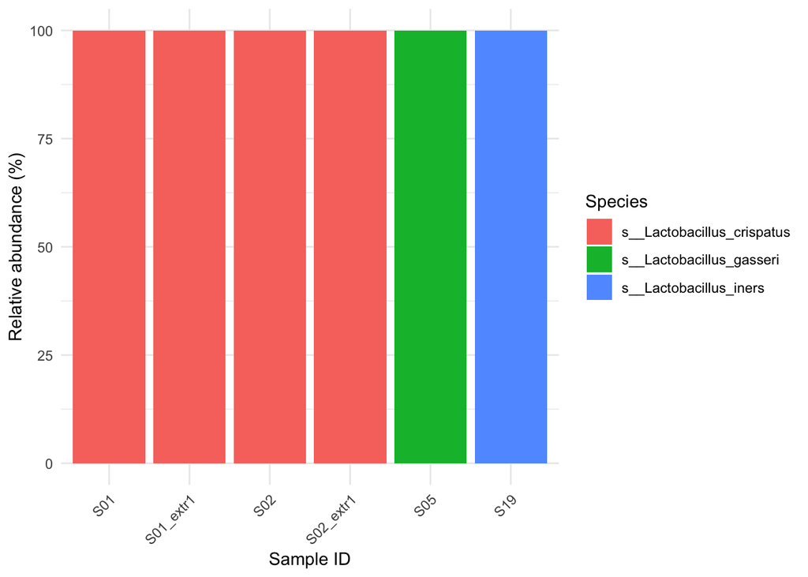

```r
#############################
# PLOT RE-SEQUENCED SAMPLES #
#############################
n <- names(select(tissue_counts, contains("extr1")))
s <- str_remove(n, "_extr1")
n <- c(n, s) # samples sequenced twice

#inspect the read levels for samples sequenced twice:
df_long <- tissue_renorm %>%
  filter(grepl("species", .$level)) %>%
  # retain only the species and strain info:
  mutate(clade_name = str_extract(clade_name, "s__.+")) %>%
  pivot_longer(
    cols = where(is.double),
    names_to = "samples",
    values_to = "abundance"
  ) %>%
  filter(samples %in% n) %>%
  filter(abundance != 0)

ggplot(df_long, aes(x = samples, y = abundance, fill = clade_name)) +
  geom_col(position = "stack") +
  labs(
    x = "Sample ID",
    y = "Relative abundance (%)",
    fill = "Species"
  ) +
  theme_minimal() +
  theme(
    axis.text.x = element_text(angle = 45, hjust = 1)
  )
```

Of the eight samples that were sequenced twice within the same sequencing run, only two were successfully sequenced both times — samples S01 and S02. Both showed 100% relative abundance of *Lactobacillus crispatus*.

### Save renormalized counts without spike-in

```r
#####################################
# REMOVE ZERO AND LOW COUNT SAMPLES #
#####################################
tissue_renorm_filt <- tissue_renorm %>%
  select(-any_of(samples_to_remove$svamp_ID)) %>%
  # removes the second sequencing of sample S01 and S02:
  select(-ends_with("_extr1"))

write_csv(
  tissue_renorm_filt,
  "../Results/Tissue_QC/Metageonome_all_tissue_metaphlan_no_spikein.csv"
)
write_csv(
  count_info_tissue_no_spike,
  "../Results/Tissue_QC/Read_count_info_tissue_no_spikein.csv"
)

# tissue_renorm_filt <- read_csv("../Results/Tissue_QC/Metageonome_all_tissue_metaphlan_no_spikein.csv")
```

## Bacterial counts after spike-in removal

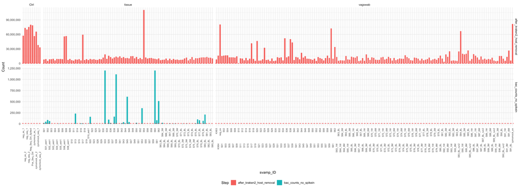

```r
#########################################################
# VISUALIZE RE-NORMALIZED COUNTS AFTER SPIKE-IN REMOVAL #
#########################################################
df_long <- count_info_tissue_no_spike %>%
  select(svamp_ID, bac_counts_no_spikein) %>%
  # remove controls:
  filter(!(str_detect(.$svamp_ID, "_ex_|_seq|_Seq"))) %>%
  pivot_longer(cols = 2, names_to = "step", values_to = "count") %>%
  mutate(type = "tissue") %>%
  # cap sample S33 and S60 at to get a better y-axis actual value is 1.7e+07 and 7693787:
  mutate(count = ifelse(grepl("S33|S60", .$svamp_ID), 1200000, .$count)) %>%
  bind_rows(count_info, .) %>%
  filter(step != "after_fastp")

p <- ggplot(df_long, aes(x = svamp_ID, y = count, fill = step)) +
  geom_col(width = 0.7, position = "dodge") +
  facet_grid(step ~ type, scales = "free", drop = TRUE, space = "free_x") +
  scale_x_discrete(guide = guide_axis(n.dodge = 2)) +
  scale_y_continuous(labels = label_comma()) + # <-- commas
  theme_minimal() +
  theme(
    legend.position = "bottom",
    axis.text.x = element_text(angle = 90, vjust = 0.5, hjust = 1, size = 7)
  ) +
  labs(x = "svamp_ID", y = "Count", fill = "Step") +
  # Add red horizontal lines
  #geom_hline(yintercept = 20000000, color = "red", linetype = "dashed") +
  geom_hline(yintercept = 10000, color = "red", linetype = "dashed")

p
```

```r
ggsave(
  "../Results/Tissue_QC/counts_renorm_plot.png",
  p,
  width = 22,
  height = 8,
  bg = "white"
)
```

This plot shows the renormalized read counts of tissue samples after removal of the spike-in bacterium *Alicyclobacillus acidiphilus*. Samples S33 and S60 are capped at 1,200,000 reads to better visualize samples with low read counts. Their actual counts are 1.7 × 10⁷ and 7,693,787, respectively. The red dashed line marks 10,000 reads. A total of 55 samples had zero bacterial reads after spike-in removal.

36 tissue samples have data after excluding one sample for low reads. Of these, S01 and S02 were sequenced twice, resulting in 34 unique tissue samples being successfully sequenced.

```r
# check that the samples are the same as Gabriella found
smpl_35 <- read_delim("/Users/vilkal/Tissue_35_sampleID_list.csv", delim = ";")
```

[output not shown]

```r
n <- count_info_tissue_no_spike %>%
  select(svamp_ID, Flowcell_L1_bc) %>%
  deframe()
df <- count_info_tissue_no_spike %>% select(Flowcell_L1_bc, svamp_ID) # %>% deframe()


G <- setdiff(smpl_35$Flowcell_L1_bc, n[names(tissue_renorm_filt)[-c(1, 2)]])
M <- setdiff(n[names(tissue_renorm_filt)[-c(1, 2)]], smpl_35$Flowcell_L1_bc)

# samples in Gabriella's table but not in my table
df %>% filter(Flowcell_L1_bc %in% G)
```

```
# A tibble: 3 × 2
  Flowcell_L1_bc    svamp_ID
  <chr>             <chr>
1 E250043326_L01_74 S01_extr1
2 E250043326_L01_76 S02_extr1
3 E250043326_L01_57 S19
```

```r
# S19, S01_extr1 and S02_extr1 was missing from my samples

# samples in my table but not in Gabriella's
df %>% filter(Flowcell_L1_bc %in% M)
```

```
# A tibble: 3 × 2
  Flowcell_L1_bc     svamp_ID
  <chr>              <chr>
1 E250043278_L01_116 Pos_Seq_Ctrl
2 E250043326_L01_41  S05
3 E250043278_L01_127 S45
```

```r
# S05, S45 is missing from Gabriellas samples
```

## Visualize tissue data

```r
# Section ####
# order samples by percentage of specified taxa based on assigned microbiome group
# NB! I found that I got a cleaner looking graph by using gardnerella also for L4 (typ = identity)
factor.fun <- function(df) {
  # title1 ----
  l <- c(
    "Lactobacillus" = "crispatus",
    "iners" = "iners",
    "Gardnerella" = "Gardnerella",
    "other" = "Gardnerella"
  )
  imap(
    l,
    ~ filter(df, gr == .y & str_detect(clade_name, .x)) %>%
      arrange(., desc(abundance)) %>%
      select(sample, gr) %>%
      unique() %>%
      pull(., "sample")
  ) %>%
    unlist()
}
gr.fun <- function(df) {
  # clean up the clade_name column
  df <- df %>%
    group_by(sample) %>%
    arrange(desc(abundance)) %>%
    mutate(clade_name = str_replace_all(clade_name, "\\w__", "")) %>%
    mutate(clade_name = str_replace_all(clade_name, "\\||_", " ")) %>%
    ungroup()

  groups <- df %>%
    group_by(sample) %>%
    mutate(gr = str_extract(first(clade_name), "^\\w+")) %>%
    mutate(
      gr = case_when(
        str_detect(gr, "Lactobacillus|Gardnerella") ~ gr,
        TRUE ~ "other"
      )
    ) %>%
    mutate(
      gr = ifelse(
        str_detect(first(clade_name), "iners"),
        "iners",
        gr
      )
    ) %>%
    ungroup() %>%
    select(sample, gr) %>%
    unique() %>%
    deframe()
  return(groups)
}

##################
# COLOUR PALLETS #
##################
#### colour pallet ####

pal_list <- list(
  Lactobacillus <- c(
    "#87c7c0",
    "#a9e7e4",
    "#c2ebe2",
    "#A8EDFC",
    "#A8EDFC",
    "#A8EDFC",
    "#7fe2e9",
    "#7fe2e9",
    "#83dafb",
    "#83dafb"
  ),
  Gardnerella <- c("#be6a7d", "#8a3c4eff", "#d45265ff", "#f07487ff", "#f1a6b1"),
  Prevotella <- c(
    "#e06806ff",
    "#e2771fff",
    "#e99a59ff",
    "#f0c497ff",
    "#eebc89ff"
  ),
  Bacillus <- c("#59a14f", "#77a371ff", "#71a38cff", "#9cd694ff", "#b5ebaeff"),
  other <- c(
    "#E3E6AD",
    "#F8D0A4",
    "#c4ce96",
    "#9aacce",
    "#e1caff",
    "#abc5bf",
    "#ffffd4",
    "#c0a2c1",
    "#c8ffd5",
    "#c8ffd5",
    "#afb7ee",
    "#ffc8d9",
    "#ffc8d9",
    "#e7b993",
    "#c8ffd5",
    "#c4cea9",
    "#a1b37d",
    "#a6cca7",
    "#d1b9ee",
    "#88c29c",
    "#fdcc8a",
    "#91c6f7",
    "#f5f8bd",
    "#8db1c5",
    "#fab0aa",
    "#7cb6b6",
    "#96f3eb",
    "#6ececc"
  )
)

taxa_order.fun <- function(df) {
  lvls <- c("Lactobacillus", "Gardnerella", "Prevotella", "Bacillus", "other")
  gr_lvls <- lvls %>% paste0(., collapse = "|")
  d <- df_long %>%
    mutate(
      gr_lvl = ifelse(
        str_detect(clade_name, gr_lvls),
        str_extract(clade_name, gr_lvls),
        "other"
      )
    ) %>%
    group_by(gr_lvl) %>%
    arrange(desc(abundance)) %>%
    select(gr_lvl, clade_name) %>%
    ungroup() %>%
    unique() %>%
    mutate(gr_lvl = factor(.$gr_lvl, levels = lvls)) %>%
    arrange(gr_lvl) %>%
    nest(.by = "gr_lvl") %>%
    mutate(
      data = map2(
        gr_lvl,
        data,
        ~ if (.x == "other") arrange(.y, as.character(clade_name)) else .y
      )
    ) %>%
    unnest(cols = c(data))

  col <- d %>%
    group_by(gr_lvl) %>%
    mutate(col = pal_list[[cur_group_id()]][1:n()]) %>%
    ungroup() %>%
    select(-gr_lvl) %>%
    deframe()

  return(col)
}
```

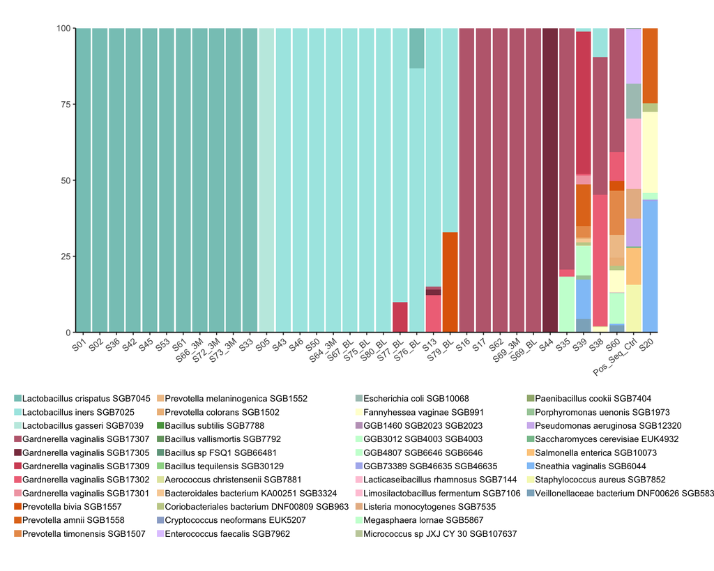

```r
# pivot longer and calculate perecentage for the 15 most abundant taxa
df_long <- tissue_renorm_filt %>%
  # select taxonomy level
  filter(grepl("strain", level)) %>%
  # retain only the species and strain info:
  mutate(clade_name = str_extract(clade_name, "s__.+")) %>%
  # removes taxa that sums to zero:
  filter(sum(c_across(where(is.double))) != 0) %>%
  # arrange acording to taxa rowsum
  arrange(desc(rowSums(across(where(is.numeric))))) %>%
  # mutate(clade_name = factor(.$clade_name, levels = .$clade_name)) %>%
  # slice_head(., n = 15) %>%
  pivot_longer(
    cols = where(is.double),
    names_to = "sample",
    values_to = "abundance"
  )

#########################
# PRETTY PLOT ADDITIONS #
#########################
df_long_ <- df_long %>%
  # clean up the clade_name column
  group_by(sample) %>%
  arrange(desc(abundance)) %>%
  mutate(taxa = str_replace_all(clade_name, "\\w__", "")) %>%
  mutate(taxa = str_replace_all(taxa, "\\||_", " ")) %>%
  ungroup() %>%

  # assigne each sample into a taxa group (one of Lactobacillus, iners, Gardnerella or other )
  # gr.fun(.) # test
  mutate(gr = gr.fun(.)[.$sample]) %>%

  # order samples by percentage of taxa within each level of "gr"
  # factor.fun(.) # test
  mutate(sample = factor(sample, levels = factor.fun(.))) %>%

  # fix taxa order:
  mutate(
    clade_name = factor(.$clade_name, levels = names(taxa_order.fun(.)))
  ) %>%
  arrange(clade_name) %>%
  mutate(taxa = factor(.$taxa, levels = unique(.$taxa))) %>%

  # gets colour for each taxa
  mutate(col = taxa_order.fun(.)[.$clade_name])


####################################################
# PLOT STRAIN LEVEL ABUNDANCE OF REMAINING SAMPLES #
####################################################
col_pal <- df_long_ %>% select(taxa, col) %>% unique() %>% deframe()
colourCount = length(unique(df_long_$clade_name))
getPalette = colorRampPalette(brewer.pal(9, "Set1"))

#plot the ctrls
barplot <- ggplot(
  df_long_,
  aes(x = sample, y = abundance, fill = taxa) # round(value, digits = 3)
) +
  geom_col(width = .9, position = "stack") +
  # geom_text(aes(label = abundance), position = position_stack(vjust = 0.5)) +
  scale_fill_manual(values = col_pal) + # pal[1:colourCount]
  guides(
    fill = guide_legend(
      override.aes = list(size = 2),
      ncol = 4,
      byrow = FALSE,
      keyheight = .4,
      keywidth = .6
    )
  ) +
  theme_classic() +
  coord_cartesian(expand = F) +
  theme(
    plot.margin = unit(c(1, 2, 1, 2), "cm"),
    legend.spacing.y = unit(.5, 'cm'),
    legend.title = element_blank(),
    legend.text = element_text(margin = margin(r = .3, l = .3, unit = "pt"), ),
    axis.title = element_blank(),
    axis.text.x = element_text(angle = 40, hjust = 1),
    legend.position = "bottom"
  )

plot(barplot)
```

```r
ggsave(
  "../Results/Tissue_QC/barplot_tissue_renorm.png",
  barplot,
  width = 10,
  height = 8,
  bg = "white"
)
```

## Filter taxonomy

```r
# final
############################
# IDENTIFY TAXA TO FILTER #
###########################
n_samples <- select(tissue_renorm_filt, starts_with("S")) %>% ncol() # number of good samples

# keep taxa with at least 0.005% in at least 6% (2 out of 34) of samples, or at least 2% relative abundance in at least 1 sample.

# Step 1. split clade name into seperate columns
temp <- tissue_renorm_filt %>%
  select(-Pos_Seq_Ctrl) %>% # removes ctrl sample
  separate(
    col = clade_name,
    into = taxonomy,
    sep = "\\|",
    #remove = FALSE,
    fill = "right"
  ) %>%
  filter(if_any(where(is.double), ~ .x > 0))

# Step 2. Identify the strains to remove
strains_to_remove <- temp %>%
  filter(level == "strain") %>%
  filter(
    !(rowSums(across(where(is.double), ~ .x > 0.005)) >=
      round(0.06 * n_samples) |
      rowSums(across(where(is.double), ~ .x >= 2)) >= 1)
  )

strains_to_remove %>%
  arrange(desc(rowSums(across(where(is.numeric))))) %>%
  # removes samples with colsum = zero:
  select(
    -where(~ is.numeric(.x) && sum(.x) == 0)
  ) %>%
  knitr::kable(., digits = 1)
```

| kingdom | phylum | class | order | family | genus | species | strain | level | S20 | S33 | S38 | S39 | S60 |
| --- | --- | --- | --- | --- | --- | --- | --- | --- | --- | --- | --- | --- | --- |
| k__Bacteria | p__Bacteroidota | c__Bacteroidia | o__Bacteroidales | f__Porphyromonadaceae | g__Porphyromonas | s__Porphyromonas_uenonis | t__SGB1973 | strain | 0.0 | 0.0 | 0.0 | 1.5 | 0.0 |
| k__Bacteria | p__Bacteroidota | c__Bacteroidia | o__Bacteroidales | f__Bacteroidales_unclassified | g__Bacteroidales_unclassified | s__Bacteroidales_bacterium_KA00251 | t__SGB3324 | strain | 0.0 | 0.0 | 0.0 | 1.1 | 0.0 |
| k__Bacteria | p__Candidatus_Saccharibacteria | c__Candidatus_Nanoperiomorbia | o__Candidatus_Nanoperiomorbales | f__Candidatus_Nanoperiomorbaceae | g__GGB73389 | s__GGB73389_SGB46635 | t__SGB46635 | strain | 0.5 | 0.0 | 0.0 | 0.0 | 0.0 |
| k__Bacteria | p__Firmicutes | c__Bacilli | o__Lactobacillales | f__Lactobacillaceae | g__Lacticaseibacillus | s__Lacticaseibacillus_rhamnosus | t__SGB7144 | strain | 0.0 | 0.3 | 0.0 | 0.0 | 0.0 |
| k__Bacteria | p__Firmicutes | c__Bacilli | o__Lactobacillales | f__Aerococcaceae | g__Aerococcus | s__Aerococcus_christensenii | t__SGB7881 | strain | 0.0 | 0.0 | 0.2 | 0.0 | 0.0 |
| k__Bacteria | p__Bacteroidota | c__Bacteroidia | o__Bacteroidales | f__Muribaculaceae | g__GGB1460 | s__GGB1460_SGB2023 | t__SGB2023 | strain | 0.0 | 0.0 | 0.0 | 0.0 | 0.1 |
| k__Bacteria | p__Actinobacteria | c__Actinomycetia | o__Micrococcales | f__Micrococcaceae | g__Micrococcus | s__Micrococcus_sp_JXJ_CY_30 | t__SGB107637 | strain | 0.0 | 0.0 | 0.0 | 0.0 | 0.0 |

```r
# Step 3. Aggregate removed strains by higher levels
removed_all_lvls <- strains_to_remove %>%
  # pivot_longer(cols = where(is.double), names_to = "sample", values_to = "removed_abundance") %>%
  select(-level) %>%
  pivot_longer(
    cols = kingdom:strain,
    names_to = "level",
    values_to = "name"
  ) %>%
  nest(.by = c(level)) %>%
  mutate(
    data = map(
      data,
      ~ summarise(.x, across(where(is.double), ~ sum(.)), .by = c("name"))
    )
  ) %>%
  mutate(data = setNames(.[["data"]], .$level))

removed_all_lvls
```

```
# A tibble: 8 × 2
  level   data
  <chr>   <named list>
1 kingdom <tibble [1 × 35]>
2 phylum  <tibble [4 × 35]>
3 class   <tibble [4 × 35]>
4 order   <tibble [4 × 35]>
5 family  <tibble [7 × 35]>
6 genus   <tibble [7 × 35]>
7 species <tibble [7 × 35]>
8 strain  <tibble [7 × 35]>
```

```r
knitr::kable(removed_all_lvls$data[[2]], digits = 1)
```

| name | S01 | S02 | S05 | S13 | S16 | S17 | S20 | S33 | S35 | S36 | S38 | S39 | S42 | S43 | S44 | S45 | S46 | S50 | S53 | S60 | S61 | S62 | S64_3M | S66_3M | S67_BL | S69_3M | S69_BL | S72_3M | S73_3M | … |
| --- | --- | --- | --- | --- | --- | --- | --- | --- | --- | --- | --- | --- | --- | --- | --- | --- | --- | --- | --- | --- | --- | --- | --- | --- | --- | --- | --- | --- | --- | --- |
| p__Candidatus_Saccharibacteria | 0 | 0 | 0 | 0 | 0 | 0 | 0.5 | 0.0 | 0 | 0 | 0.0 | 0.0 | 0 | 0 | 0 | 0 | 0 | 0 | 0 | 0.0 | 0 | 0 | 0 | 0 | 0 | 0 | 0 | 0 | 0 | … |
| p__Firmicutes | 0 | 0 | 0 | 0 | 0 | 0 | 0.0 | 0.3 | 0 | 0 | 0.2 | 0.0 | 0 | 0 | 0 | 0 | 0 | 0 | 0 | 0.0 | 0 | 0 | 0 | 0 | 0 | 0 | 0 | 0 | 0 | … |
| p__Bacteroidota | 0 | 0 | 0 | 0 | 0 | 0 | 0.0 | 0.0 | 0 | 0 | 0.0 | 2.5 | 0 | 0 | 0 | 0 | 0 | 0 | 0 | 0.1 | 0 | 0 | 0 | 0 | 0 | 0 | 0 | 0 | 0 | … |
| p__Actinobacteria | 0 | 0 | 0 | 0 | 0 | 0 | 0.0 | 0.0 | 0 | 0 | 0.0 | 0.0 | 0 | 0 | 0 | 0 | 0 | 0 | 0 | 0.0 | 0 | 0 | 0 | 0 | 0 | 0 | 0 | 0 | 0 | … |

```r
# Step 4. get longer format and add back clade_names
# function to get clade name
get_full_clade.fun <- function(df) {
  # This will add a new column called match_clade
  # with the full clade_name that ends with the string from tissue_renorm_filt$clade_name
  df %>%
    mutate(
      match_clade = map_chr(
        name,
        ~ {
          hit <- tissue_renorm_filt$clade_name[str_detect(
            tissue_renorm_filt$clade_name,
            paste0(.x, "$")
          )]
          if (length(hit) > 0) hit[1] else NA_character_
        }
      )
    ) %>%
    select(match_clade) %>%
    pull()
}

removals <- removed_all_lvls %>%
  unnest(cols = data) %>%
  mutate(clade_name = get_full_clade.fun(.))

#############################
# FILTER AT ALL TAXA LEVELS #
############################
# Step 5. Subtract from higher levels
tissue_adjusted <- tissue_renorm_filt %>%
  # Join percentages to be subtracted
  left_join(
    select(removals, -name, -level),
    by = "clade_name",
    suffix = c("", "_rm")
  ) %>%
  # Subtract sample-wise values
  mutate(
    across(
      matches("^S\\d\\d$"),
      ~ .x - coalesce(get(paste0(cur_column(), "_rm")), 0)
    )
  ) %>%
  select(-ends_with("_rm"))

# test
strains_to_remove %>% pull("S39") %>% sum(.)
```

```
[1] 2.531711
```

```r
tissue_adjusted %>% filter(level == "genus") %>% pull("S39") %>% sum(.)
```

```
[1] 97.46829
```

```r
#####################################
# RENORMALIZED FILTERED TAXA VALUES #
#####################################
# Step 6. Re-normalize so each sample sums to 100
tissue_adj_norm <- tissue_adjusted %>%
  group_by(level) %>%
  mutate(
    across(
      matches("^S\\d\\d$"),
      ~ .x * 100 / sum(.x, na.rm = TRUE)
    )
  ) %>%
  ungroup()

# test
tissue_adj_norm %>% filter(level == "genus") %>% pull("S39") %>% sum(.)
```

```
[1] 100
```

### Save filtered table

```r
tissue_adj_norm %>%
  select(-Pos_Seq_Ctrl) %>%
  arrange(level) %>%
  write_csv(
    .,
    "../Results/Tissue_QC/Metageonome_all_tissue_metaphlan_taxa_filt.csv"
  )
```

## Rarefy

```r
#install.packages("phyloseq")
#if (!require("BiocManager", quietly = TRUE))
#    install.packages("BiocManager")

#BiocManager::install("phyloseq")
library(phyloseq)
#rarefy
# Separate the 'totalBacterialReads' column
total_reads <- mpa_renorm$bac_counts_no_spikein

# Subset to just taxa (exclude metadata columns)
# This assumes all taxa columns come before or are easily selected
relabund_mat <- mpa_renorm[, 1:233]

# Multiply relative abundance by total reads, round to get integer counts
count_mat <- round(as.matrix(relabund_mat) * total_reads / 100)
row.names(count_mat) <- mpa_renorm$Flowcell_L1_bc

meta <- sample_data(mpa_renorm[, c(234:259)])
rownames(meta) <- mpa_renorm$Flowcell_L1_bc

otu <- otu_table(count_mat, taxa_are_rows = FALSE)

# Make sure it's a matrix and rownames match taxa
#tax_mat <- as.matrix(tax_df)  # columns = taxonomic ranks
#tax <- tax_table(tax_mat)

taxa_ids <- colnames(count_mat)
tax_mat <- as.matrix(taxa_ids) # columns = taxonomic ranks

tax <- tax_table(tax_mat)
rownames(tax) <- tax_mat

physeq <- phyloseq(otu, meta, tax)

set.seed(123)
physeq_rare <- rarefy_even_depth(
  physeq,
  sample.size = min(sample_sums(physeq)),
  rngseed = 123
)
#rarefy to 2243
#
physeq_relab <- transform_sample_counts(physeq_rare, function(x) {
  x / sum(x) * 100
})

new_df <- as.data.frame(otu_table(physeq_relab))
new_df$Flowcell_L1_bc <- row.names(new_df)
```

## Plot vagswab control samples

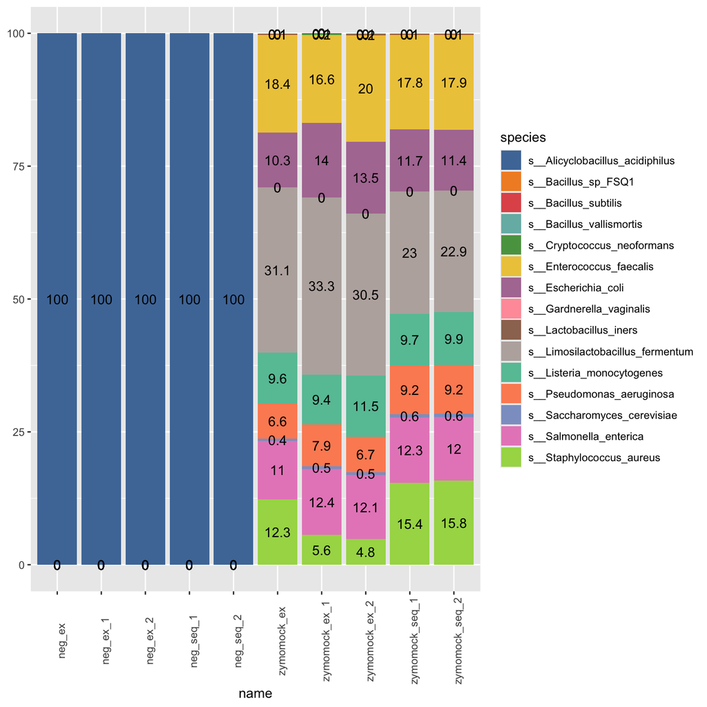

```r
controls_tissue <- names(tissue_counts)[str_detect(names(tissue_counts), "Seq")]
controls_vagswab <- names(vagswab_counts)[str_detect(
  names(vagswab_counts),
  "ex|seq"
)]
taxonomy <- c(
  "kingdom",
  "phylum",
  "class",
  "order",
  "family",
  "genus",
  "species",
  "strain"
)

# select taxa level and control samples
ctrls <- vagswab_counts %>%
  # select control samples
  select(clade_name, any_of(controls_vagswab)) %>%
  # split calde names into seperate columns:
  separate(
    col = clade_name,
    into = taxonomy,
    sep = "\\|",
    fill = "right"
  ) %>%
  # filter out only species level taxonomy:
  filter(!is.na(species)) %>%
  filter(is.na(strain)) %>%
  select(species, any_of(controls_vagswab))

# arrange by most abundant taxa
# and remove lowly abundant taxa across all controls
ctrls_top <- ctrls %>%
  mutate(tot_ctrls = rowSums(ctrls[, 2:ncol(.)], na.rm = T)) %>%
  arrange(-tot_ctrls) %>%
  filter(tot_ctrls > 0.000001)

# pivot longer and calculate perecentage for the 15 most abundant taxa
df_ctrls <- ctrls_top %>%
  select(-tot_ctrls) %>%
  slice_head(., n = 15) %>%
  pivot_longer(
    cols = -species,
    names_to = "name",
    values_to = "value"
  ) %>%
  mutate_at("value", as.numeric) %>%
  mutate(across(where(is.numeric), ~ round(., 1)))
#filter(value>0)

#################################################
# PLOT TOP 15 TAXA ABUNDANCE OF CONTROL SAMPLES #
#################################################
colourCount = length(unique(df_ctrls$species))
getPalette = colorRampPalette(brewer.pal(9, "Set1"))

#plot the ctrls
ctrls_barplot <- ggplot(
  df_ctrls,
  aes(x = name, y = round(value, digits = 3), fill = species)
) +
  geom_bar(stat = "identity") +
  geom_text(aes(label = value), position = position_stack(vjust = 0.5)) +
  scale_fill_manual(values = pal[1:colourCount]) +
  theme(axis.title.y = element_blank()) +
  theme(axis.text.x = element_text(angle = 90))

plot(ctrls_barplot)
```

```r
ggsave(
  filename = "Ctrls_barplot.png",
  plot = ctrls_barplot,
  width = 12
)
```